# Wine Sales

# Whining about Wine Sales

## Overview

In this report we attempt to build a model for wine sales as would be predicted by a number of factors about the wine and its packaging. In the end a zero inflated poisson model seems to be the best model. Particularly important to sales variables seem to consist of Label Appeal, Acid Index, Stars and to a lesser extent Alcohol.

## Data Exploration

Below is a short description of the variables of interest in the data set:

| Variable Name | Description | Import |
| --- | --- | --- |
| Index | Identification | Not used |
| Target | Number of cases purchased | Response variable |
| ————— | ————– | ——— |
| AcidIndex | Proprietary total acidity measure |  |
| Alcohol | Alcohol content |  |
| Chlorides | Chloride content |  |
| Density | Density of Wine |  |
| FixedAcidity | Fixed Acidity |  |
| FreeSulfurDioxide | Sulfur Dioxide Content |  |
| Label Appeal | Marketing Score indicating appeal of label | Expected positive |
| ResidualSugar | Residual Sugar |  |
| STARS | Wine rating by experts | Positive |
| Sulphates | Sulfate content |  |
| TotalSulfurDioxide | Total Sulfur Dioxide |  |
| VolatileAcidity | Volatile Acid content |  |
| pH | pH of wine |  |

On a first inspection, it was obvious that many variables had at least some missing data.

A sample from the training dataset is provided below:

### Training Dataset

Table continues below

| TARGET | INDEX | FixedAcidity | VolatileAcidity | CitricAcid | ResidualSugar |
| --- | --- | --- | --- | --- | --- |
| 3 | 1 | 3.2 | 1.16 | -0.98 | 54.2 |
| 3 | 2 | 4.5 | 0.16 | -0.81 | 26.1 |
| 5 | 4 | 7.1 | 2.64 | -0.88 | 14.8 |
| 3 | 5 | 5.7 | 0.385 | 0.04 | 18.8 |
| 4 | 6 | 8 | 0.33 | -1.26 | 9.4 |
| 0 | 7 | 11.3 | 0.32 | 0.59 | 2.2 |

Table continues below

| Chlorides | FreeSulfurDioxide | TotalSulfurDioxide | Density | pH |
| --- | --- | --- | --- | --- |
| -0.567 | NA | 268 | 0.9928 | 3.33 |
| -0.425 | 15 | -327 | 1.028 | 3.38 |
| 0.037 | 214 | 142 | 0.9952 | 3.12 |
| -0.425 | 22 | 115 | 0.9964 | 2.24 |
| NA | -167 | 108 | 0.9946 | 3.12 |
| 0.556 | -37 | 15 | 0.9994 | 3.2 |

| Sulphates | Alcohol | LabelAppeal | AcidIndex | STARS |
| --- | --- | --- | --- | --- |
| -0.59 | 9.9 | 0 | 8 | 2 |
| 0.7 | NA | -1 | 7 | 3 |
| 0.48 | 22 | -1 | 8 | 3 |
| 1.83 | 6.2 | -1 | 6 | 1 |
| 1.77 | 13.7 | 0 | 9 | 2 |
| 1.29 | 15.4 | 0 | 11 | NA |

### Check Data types and Missing values

The datasets both have missing values. There are 3 categorical variables (`LabelAppeal`,`AcidIndex`,`STARS`), 11 continuous variables and the target variable is categorical.

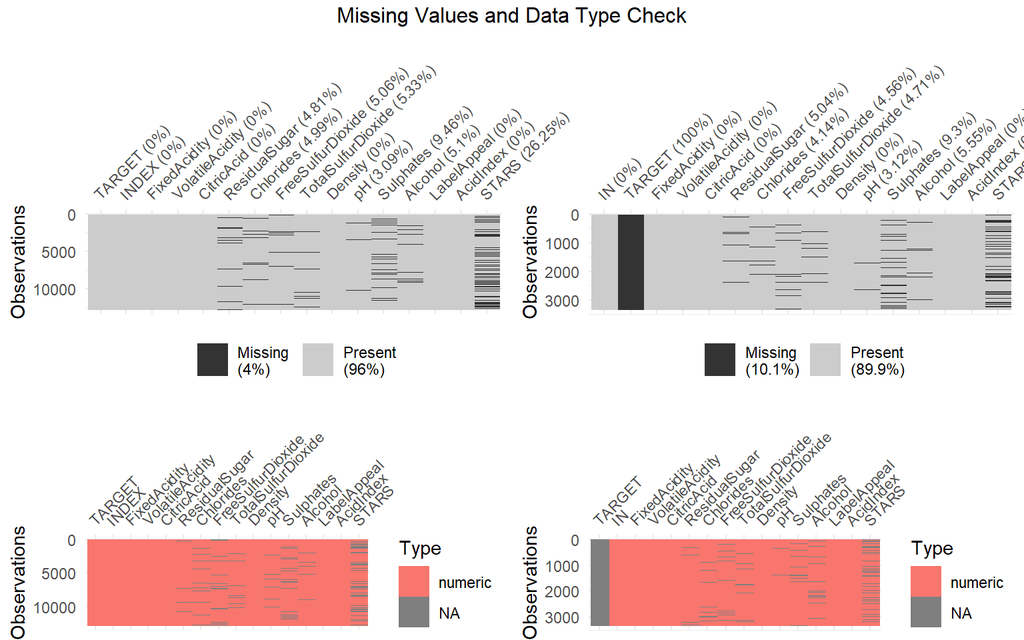

Missing Values and Data Type Check

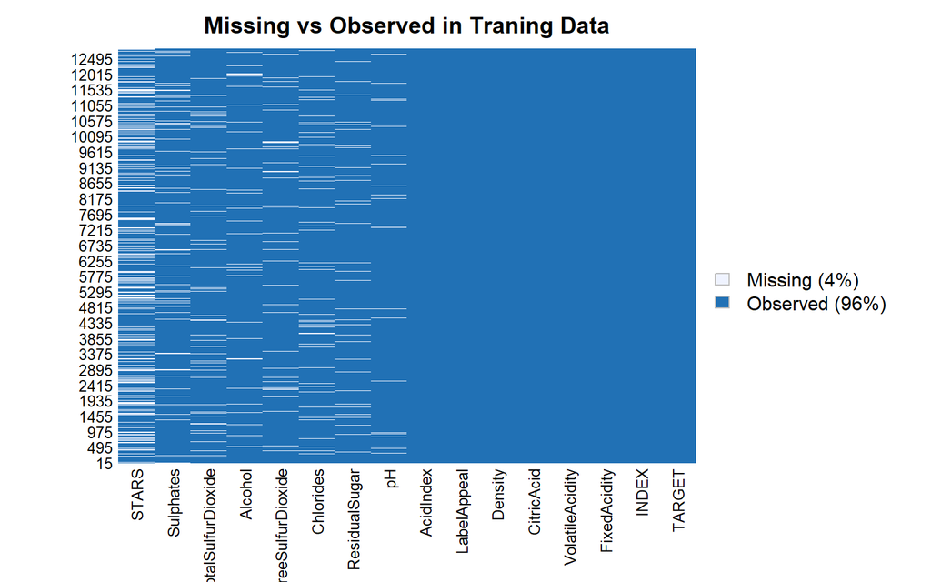

|  | Non_NAs | NAs | NA_Percent |
| --- | --- | --- | --- |
| **TARGET** | 12795 | 0 | 0 |
| **INDEX** | 12795 | 0 | 0 |
| **FixedAcidity** | 12795 | 0 | 0 |
| **VolatileAcidity** | 12795 | 0 | 0 |
| **CitricAcid** | 12795 | 0 | 0 |
| **ResidualSugar** | 12179 | 616 | 0.04814 |
| **Chlorides** | 12157 | 638 | 0.04986 |
| **FreeSulfurDioxide** | 12148 | 647 | 0.05057 |
| **TotalSulfurDioxide** | 12113 | 682 | 0.0533 |
| **Density** | 12795 | 0 | 0 |
| **pH** | 12400 | 395 | 0.03087 |
| **Sulphates** | 11585 | 1210 | 0.09457 |
| **Alcohol** | 12142 | 653 | 0.05104 |
| **LabelAppeal** | 12795 | 0 | 0 |
| **AcidIndex** | 12795 | 0 | 0 |
| **STARS** | 9436 | 3359 | 0.2625 |

### Data Statistics Summary

The data types in the raw dataset are all ‘doubles’, however the counter `INDEX` and the response variable `target` are categorical.

The statistics of all variables are listed below:

Table continues below

| TARGET | FixedAcidity | VolatileAcidity | CitricAcid |
| --- | --- | --- | --- |
| Min. :0.000 | Min. :-18.100 | Min. :-2.7900 | Min. :-3.2400 |
| 1st Qu.:2.000 | 1st Qu.: 5.200 | 1st Qu.: 0.1300 | 1st Qu.: 0.0300 |
| Median :3.000 | Median : 6.900 | Median : 0.2800 | Median : 0.3100 |
| Mean :3.029 | Mean : 7.076 | Mean : 0.3241 | Mean : 0.3084 |
| 3rd Qu.:4.000 | 3rd Qu.: 9.500 | 3rd Qu.: 0.6400 | 3rd Qu.: 0.5800 |
| Max. :8.000 | Max. : 34.400 | Max. : 3.6800 | Max. : 3.8600 |
| NA | NA | NA | NA |

Table continues below

| ResidualSugar | Chlorides | FreeSulfurDioxide | TotalSulfurDioxide |
| --- | --- | --- | --- |
| Min. :-127.800 | Min. :-1.1710 | Min. :-555.00 | Min. :-823.0 |
| 1st Qu.: -2.000 | 1st Qu.:-0.0310 | 1st Qu.: 0.00 | 1st Qu.: 27.0 |
| Median : 3.900 | Median : 0.0460 | Median : 30.00 | Median : 123.0 |
| Mean : 5.419 | Mean : 0.0548 | Mean : 30.85 | Mean : 120.7 |
| 3rd Qu.: 15.900 | 3rd Qu.: 0.1530 | 3rd Qu.: 70.00 | 3rd Qu.: 208.0 |
| Max. : 141.150 | Max. : 1.3510 | Max. : 623.00 | Max. :1057.0 |
| NA’s :616 | NA’s :638 | NA’s :647 | NA’s :682 |

Table continues below

| Density | pH | Sulphates | Alcohol |
| --- | --- | --- | --- |
| Min. :0.8881 | Min. :0.480 | Min. :-3.1300 | Min. :-4.70 |
| 1st Qu.:0.9877 | 1st Qu.:2.960 | 1st Qu.: 0.2800 | 1st Qu.: 9.00 |
| Median :0.9945 | Median :3.200 | Median : 0.5000 | Median :10.40 |
| Mean :0.9942 | Mean :3.208 | Mean : 0.5271 | Mean :10.49 |
| 3rd Qu.:1.0005 | 3rd Qu.:3.470 | 3rd Qu.: 0.8600 | 3rd Qu.:12.40 |
| Max. :1.0992 | Max. :6.130 | Max. : 4.2400 | Max. :26.50 |
| NA | NA’s :395 | NA’s :1210 | NA’s :653 |

| LabelAppeal | AcidIndex | STARS |
| --- | --- | --- |
| Min. :-2.000000 | Min. : 4.000 | Min. :1.000 |
| 1st Qu.:-1.000000 | 1st Qu.: 7.000 | 1st Qu.:1.000 |
| Median : 0.000000 | Median : 8.000 | Median :2.000 |
| Mean :-0.009066 | Mean : 7.773 | Mean :2.042 |
| 3rd Qu.: 1.000000 | 3rd Qu.: 8.000 | 3rd Qu.:3.000 |
| Max. : 2.000000 | Max. :17.000 | Max. :4.000 |
| NA | NA | NA’s :3359 |

#### The statistics of TARGET Variable.

TARGET: Number of Cases Purchased as Actual

```
##    Min. 1st Qu.  Median    Mean 3rd Qu.    Max.    StdD    Skew    Kurt
##    0.00    2.00    3.00    3.03    4.00    8.00    1.93   -0.33   -0.88
```

# FURTHER DATA EXPLORATION

## Attributes

FixedAcidity: This variable tells us about the FixedAcidity of wine.

VolatileAcidity: This variable tells us about the Volatile Acidity content of Wine.

CitricAcid: This variable tells us about the Citric Acid Content of wine.

ResidualSugar: This variable tells us about the Residual Sugar of wine.

Chlorides: This variable tells us about the Chloride content of wine.

FreeSulfurDioxide : This variable tells us about the Sulfur Dioxide content of wine.

TotalSulfurDioxide : This variable tells us about the Total Sulfur Dioxide of Wine.

Density: This variable tells us about the Density of wine.

Sulphates: This variable tells us about the Sulphates content of wine.

Alcohol: This variable tells us about the Alcohol content.

LabelAppeal: Marketing Score indicating the appeal of label design for consumers. High numbers suggest customers like the label design.

AcidIndex: Proprietary method of testing total acidity of wine by using a weighted average.

STARS: Wine rating by a team of experts. 4 Stars = Excellent, 1 Star = Poor. A high number of stars suggests high sales.

## Outliers

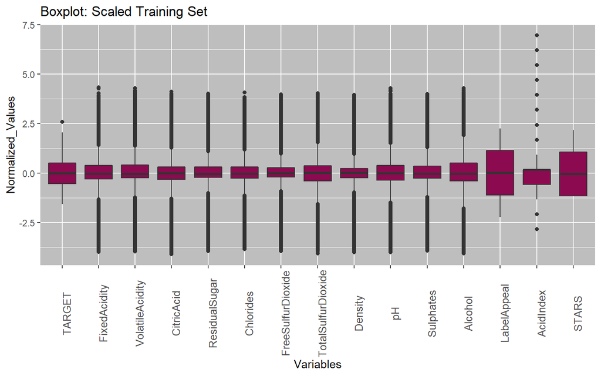

Boxplot: Scaled Training Set

## Univariate Analysis

### Response Variable

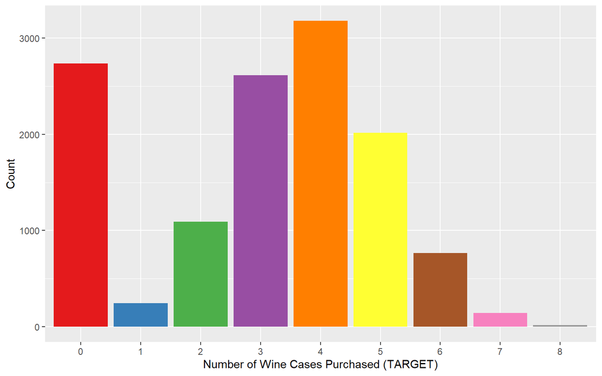

Upon examining the target variable we immediately see a normal distribution save for the large number of unsold cases.

## Correlation Plot

The correlation plot below shows how variables in the dataset are related to each other.

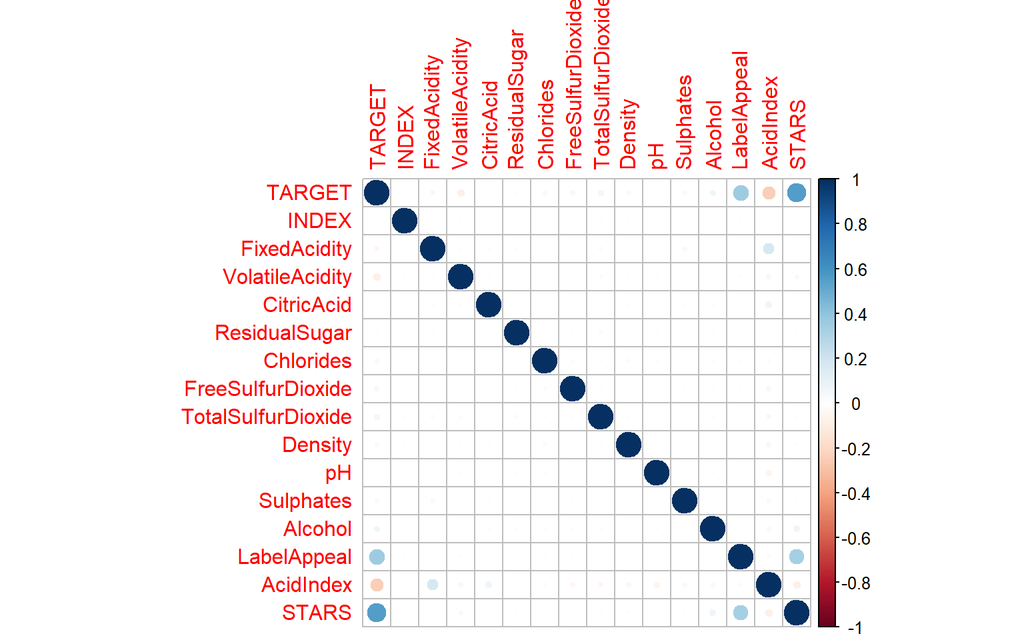

Here we see relatively little in strong correlations with almost all of the chemistry having minimal impact. Interestingly there is a some relation between star rating and label appeal. As one would expect there is a relationship with Acid index and fixed acidity.

## Density Plot

Based on the below plots we can observe that `AcidIndex` is right skewed; `AcidIndex`, `STARS`, `LabelAppeal` and `TARGET` have multi-modal distribution (as expected because they are categorical). While most others seem to be normally distributed.

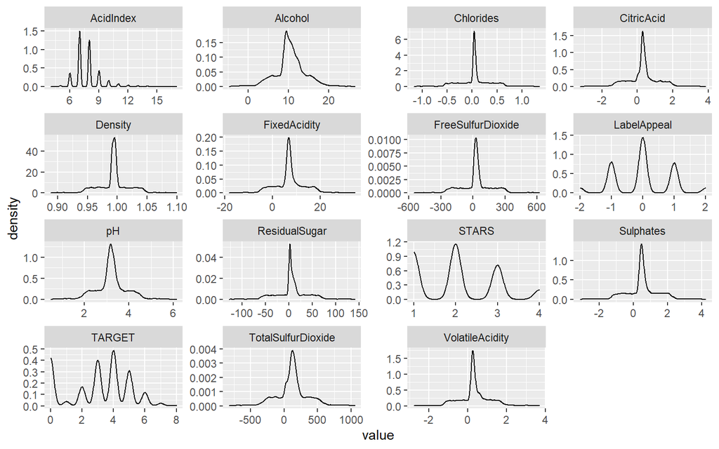

## Summarized Data Dictionary

As a summary of the data exploration process, a data dictionary is presented below:

[output not shown]

# DATA PREPARATION

In the data preparation we will split data into training and test dataset.

MICE package (Multivariate Imputation by Chained Equations)implements a method to deal with missing data. The package creates multiple imputations (replacement values) for multivariate missing data. helps in inspecting, imputing, diagnose, analyze, pool the result, and generate simulated incomplete data

‘AcidIndex’ and ‘TARGET’ have low correlation between them. We will apply a log transformation to it even if it doesn’t seem likely to provide a large model improvement.

# BUILD MODELS

## Model I: Poisson Model

### Model 1: Poisson Model without imputations

|  | Estimate | Std. Error | z value | Pr(>\|z\|) |
| --- | --- | --- | --- | --- |
| **(Intercept)** | 1.608 | 0.2796 | 5.75 | 8.902e-09 |
| **FixedAcidity** | 0.0006705 | 0.001177 | 0.5695 | 0.569 |
| **VolatileAcidity** | -0.0275 | 0.009283 | -2.963 | 0.00305 |
| **CitricAcid** | -0.003835 | 0.008519 | -0.4502 | 0.6526 |
| **ResidualSugar** | 1.828e-05 | 0.0002152 | 0.08493 | 0.9323 |
| **Chlorides** | -0.03764 | 0.02314 | -1.627 | 0.1038 |
| **FreeSulfurDioxide** | 5.671e-05 | 4.892e-05 | 1.159 | 0.2463 |
| **TotalSulfurDioxide** | 2.23e-05 | 3.177e-05 | 0.7019 | 0.4827 |
| **Density** | -0.4025 | 0.2749 | -1.464 | 0.1433 |
| **pH** | 0.0002307 | 0.01085 | 0.02127 | 0.983 |
| **Sulphates** | -0.005984 | 0.007973 | -0.7505 | 0.4529 |
| **Alcohol** | 0.003262 | 0.002004 | 1.628 | 0.1036 |
| **LabelAppeal** | 0.173 | 0.008858 | 19.53 | 6.135e-85 |
| **AcidIndex** | -0.04967 | 0.006666 | -7.451 | 9.281e-14 |
| **STARS** | 0.1929 | 0.008328 | 23.16 | 1.146e-118 |

(Dispersion parameter for poisson family taken to be 1 )

| Null deviance: | 4721 on 5143 degrees of freedom |
| --- | --- |
| Residual deviance: | 3243 on 5129 degrees of freedom |

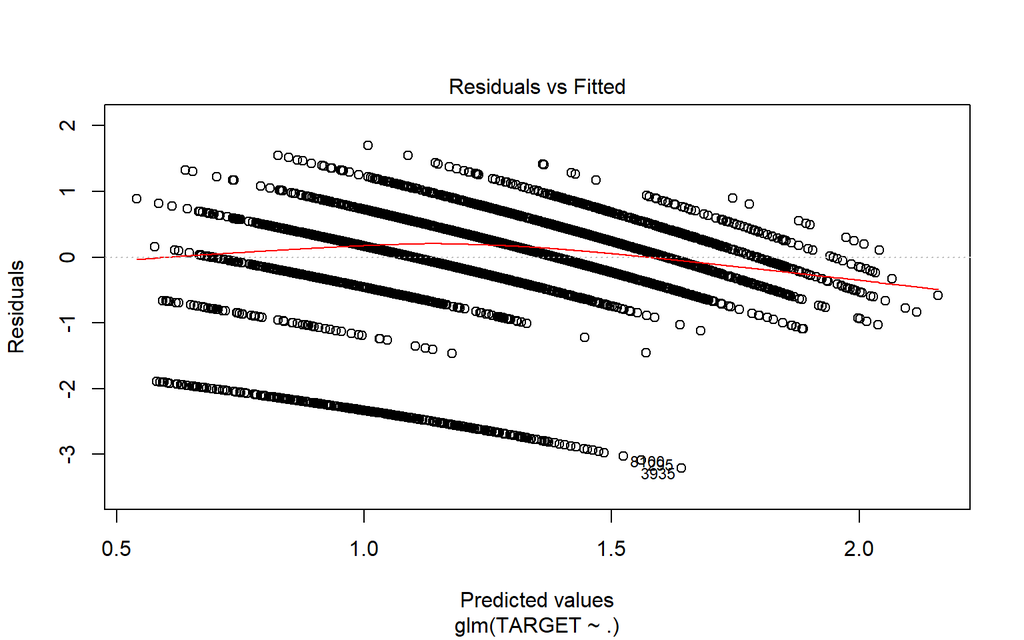

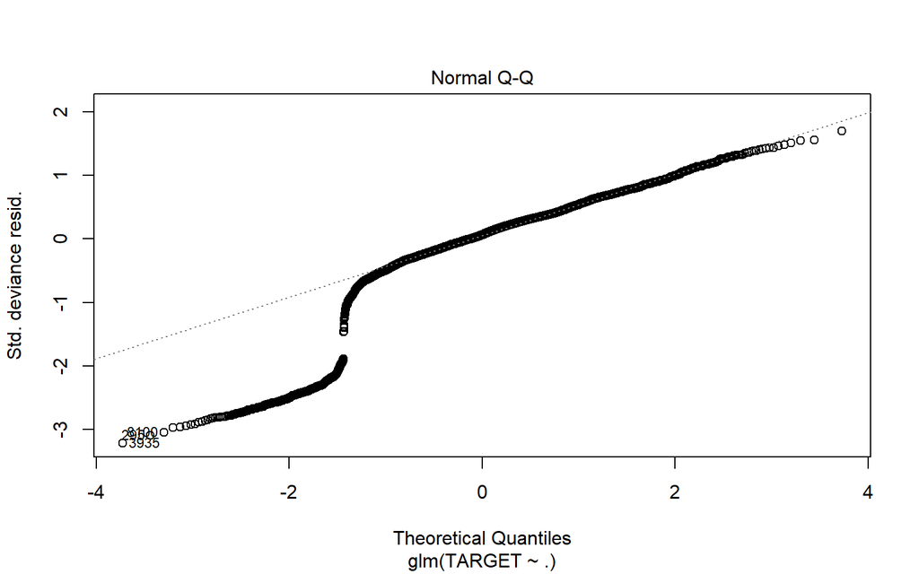

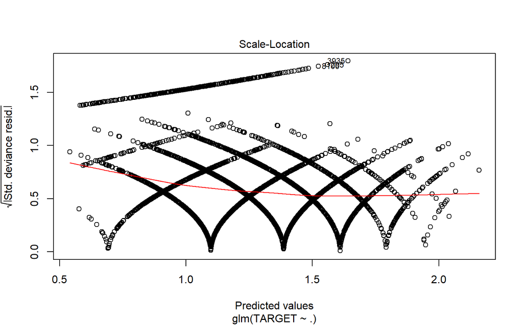

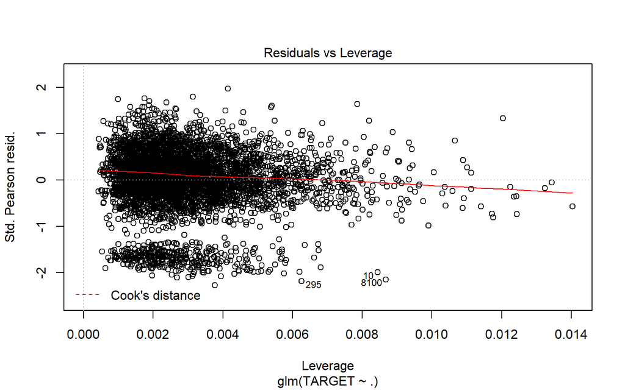

|  | Estimate | Std. Error | z value | Pr(>\|z\|) |
| --- | --- | --- | --- | --- |
| **(Intercept)** | 1.251 | 0.05472 | 22.87 | 9.626e-116 |
| **VolatileAcidity** | -0.02758 | 0.009278 | -2.973 | 0.002953 |
| **LabelAppeal** | 0.1732 | 0.008853 | 19.56 | 3.247e-85 |
| **AcidIndex** | -0.05062 | 0.006553 | -7.724 | 1.129e-14 |
| **STARS** | 0.1942 | 0.008292 | 23.42 | 2.601e-121 |

(Dispersion parameter for poisson family taken to be 1 )

| Null deviance: | 4721 on 5143 degrees of freedom |
| --- | --- |
| Residual deviance: | 3253 on 5139 degrees of freedom |

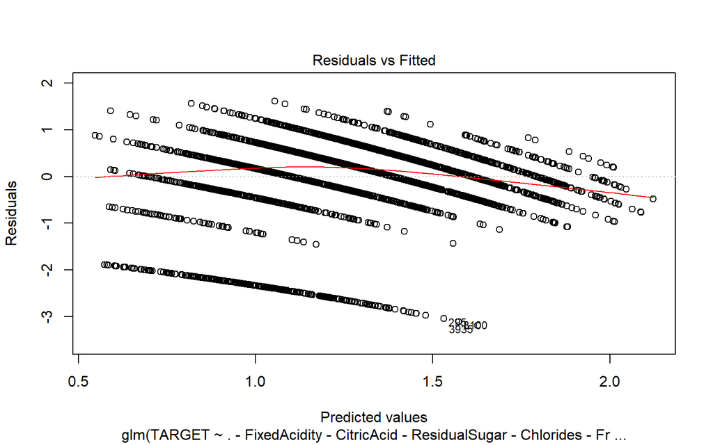

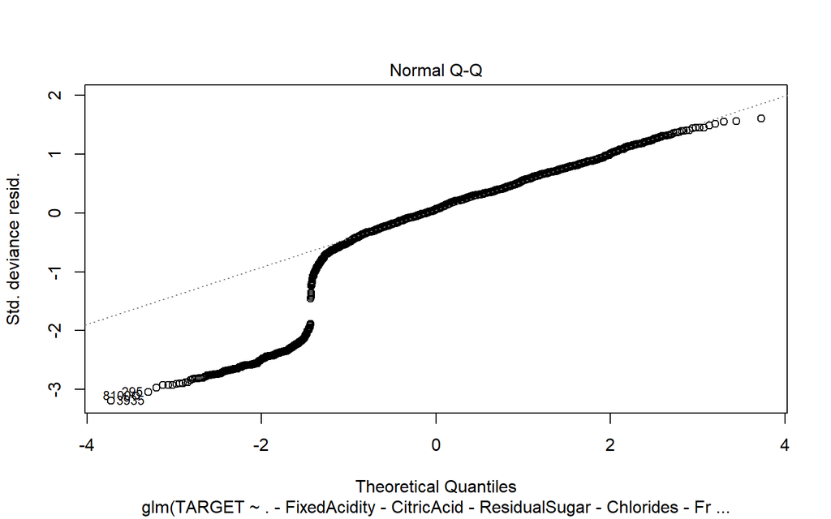

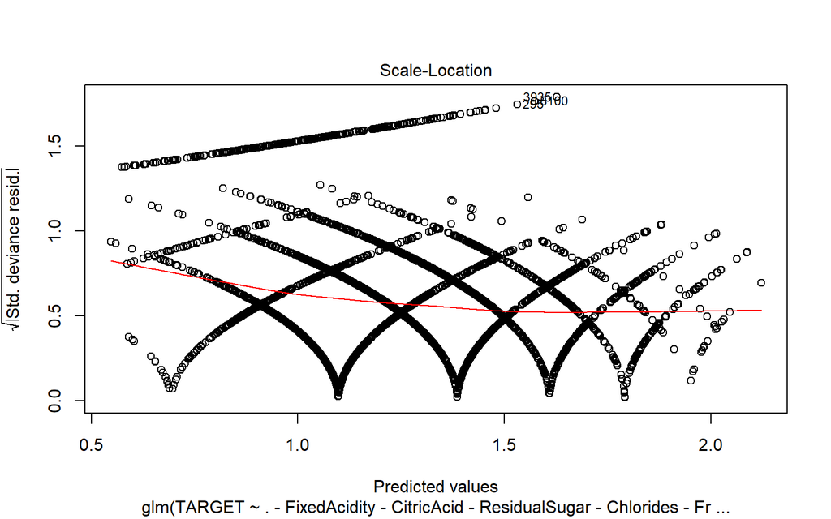

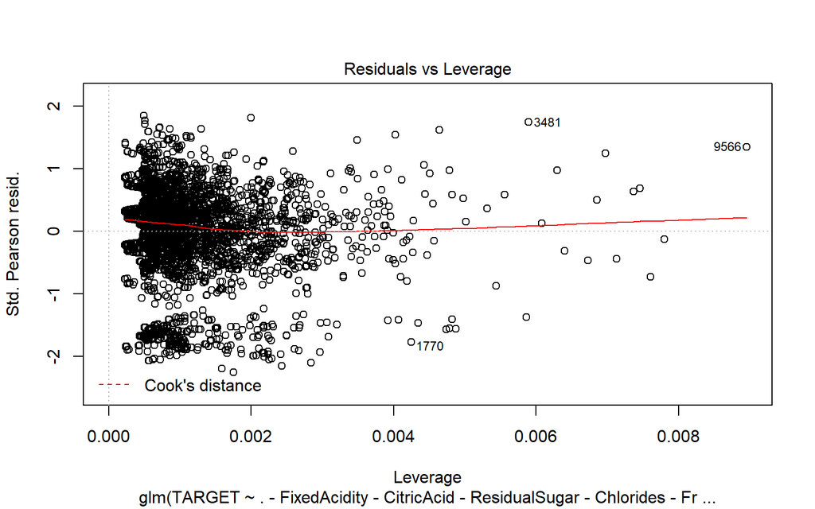

Reducing the variables in the model doesn’t have a major impact on the model, and will probably improve its performance in actual fact.

### Model 3: Poisson Model with imputations

|  | Estimate | Std. Error | z value | Pr(>\|z\|) |
| --- | --- | --- | --- | --- |
| **(Intercept)** | 2.35 | 0.228 | 10.31 | 6.517e-25 |
| **FixedAcidity** | 0.0002238 | 0.0009202 | 0.2432 | 0.8079 |
| **VolatileAcidity** | -0.04578 | 0.007286 | -6.282 | 3.334e-10 |
| **CitricAcid** | 0.00677 | 0.006566 | 1.031 | 0.3025 |
| **ResidualSugar** | 0.0001586 | 0.0001674 | 0.9473 | 0.3435 |
| **Chlorides** | -0.06268 | 0.01794 | -3.494 | 0.0004761 |
| **FreeSulfurDioxide** | 0.0001249 | 3.801e-05 | 3.285 | 0.001019 |
| **TotalSulfurDioxide** | 8.362e-05 | 2.457e-05 | 3.403 | 0.0006663 |
| **Density** | -0.3887 | 0.2145 | -1.813 | 0.06989 |
| **pH** | -0.0199 | 0.008406 | -2.367 | 0.01792 |
| **Sulphates** | -0.01035 | 0.006173 | -1.677 | 0.0936 |
| **Alcohol** | 0.002527 | 0.001557 | 1.623 | 0.1045 |
| **LabelAppeal** | 0.1429 | 0.006779 | 21.08 | 1.105e-98 |
| **AcidIndex** | -0.7543 | 0.04005 | -18.83 | 4.078e-79 |
| **STARS** | 0.3432 | 0.006241 | 55 | 0 |

(Dispersion parameter for poisson family taken to be 1 )

| Null deviance: | 18291 on 10236 degrees of freedom |
| --- | --- |
| Residual deviance: | 12767 on 10222 degrees of freedom |

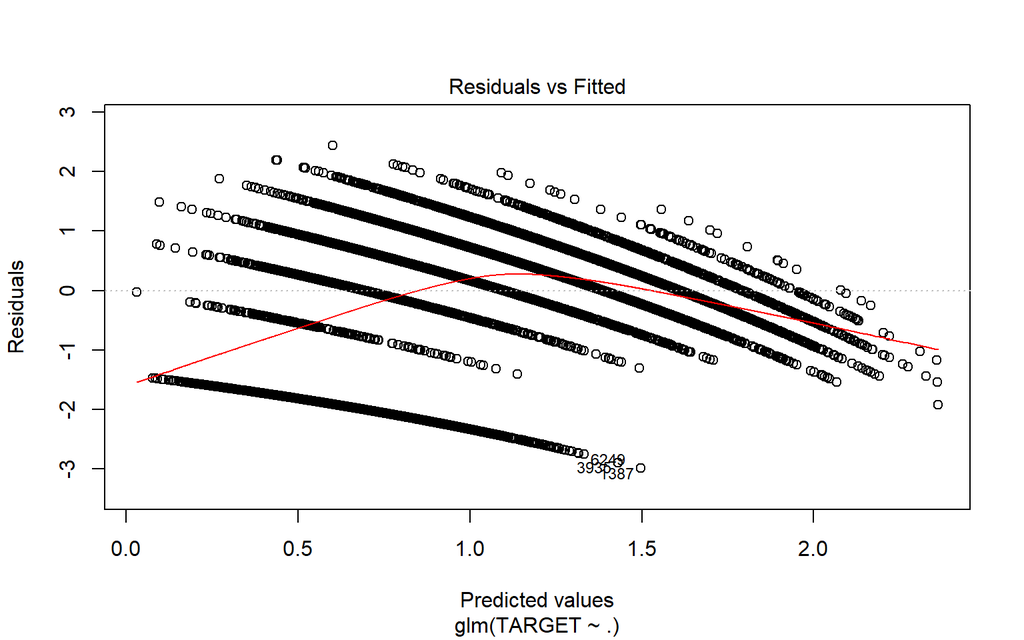

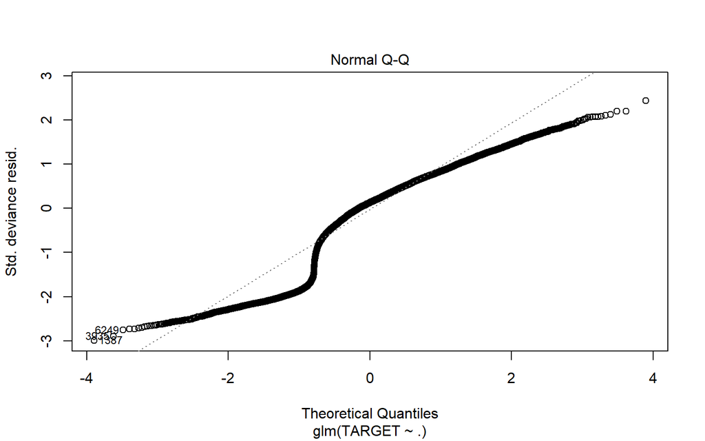

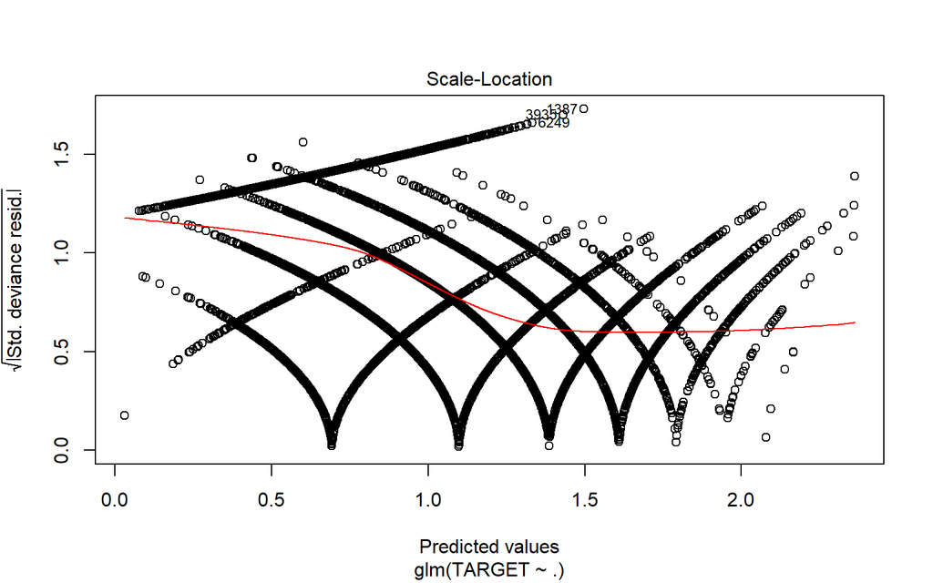

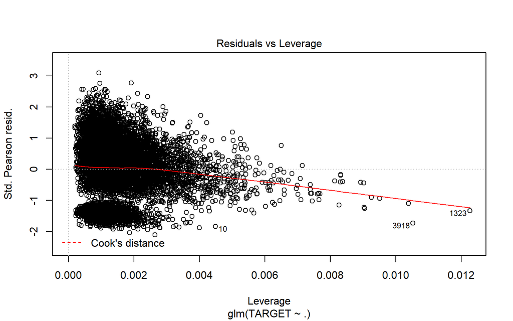

### Model 4: Poisson Model with imputations and only significant variables

|  | Estimate | Std. Error | z value | Pr(>\|z\|) |
| --- | --- | --- | --- | --- |
| **(Intercept)** | 2.001 | 0.0885 | 22.61 | 3.784e-113 |
| **VolatileAcidity** | -0.04605 | 0.007285 | -6.321 | 2.591e-10 |
| **Chlorides** | -0.06452 | 0.01793 | -3.599 | 0.0003195 |
| **FreeSulfurDioxide** | 0.0001233 | 3.8e-05 | 3.245 | 0.001173 |
| **TotalSulfurDioxide** | 8.234e-05 | 2.454e-05 | 3.355 | 0.0007935 |
| **pH** | -0.02022 | 0.008403 | -2.406 | 0.01613 |
| **Sulphates** | -0.01025 | 0.006167 | -1.661 | 0.09662 |
| **LabelAppeal** | 0.1429 | 0.006779 | 21.08 | 1.235e-98 |
| **AcidIndex** | -0.7573 | 0.03941 | -19.22 | 2.61e-82 |
| **STARS** | 0.3442 | 0.006224 | 55.3 | 0 |

(Dispersion parameter for poisson family taken to be 1 )

| Null deviance: | 18291 on 10236 degrees of freedom |
| --- | --- |
| Residual deviance: | 12775 on 10227 degrees of freedom |

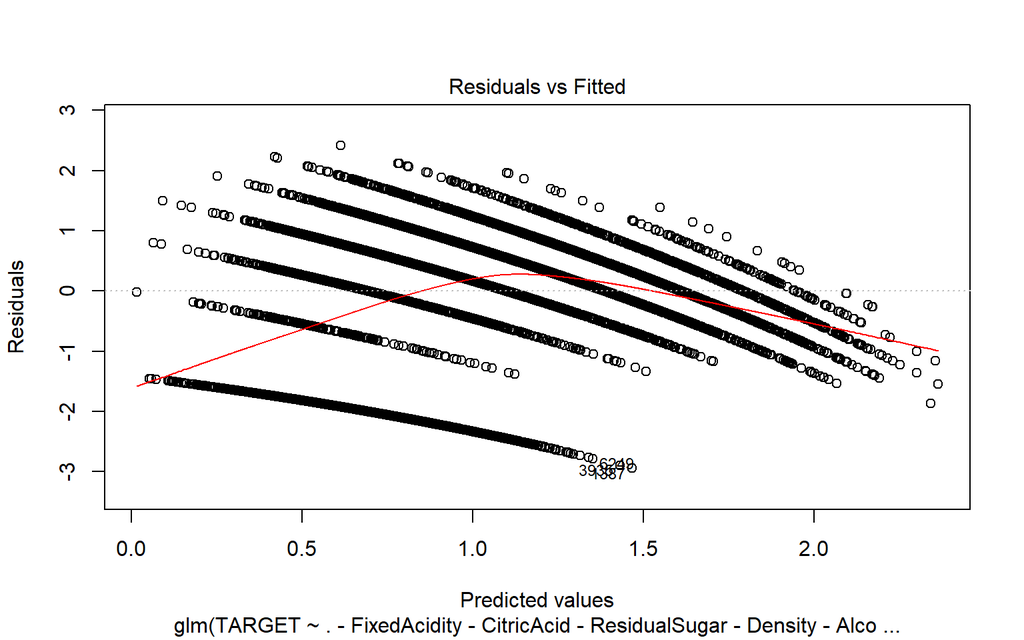

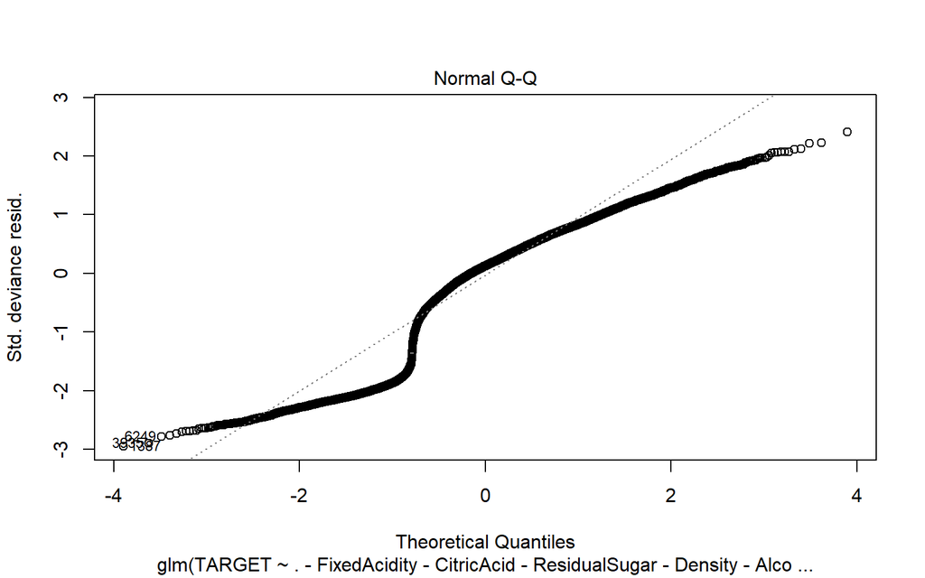

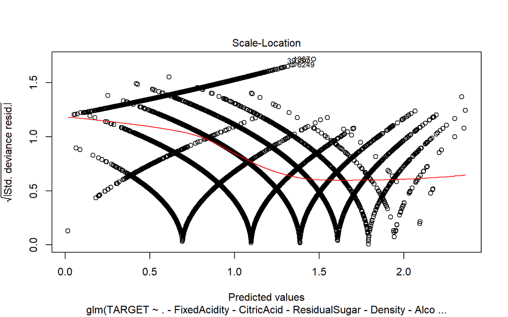

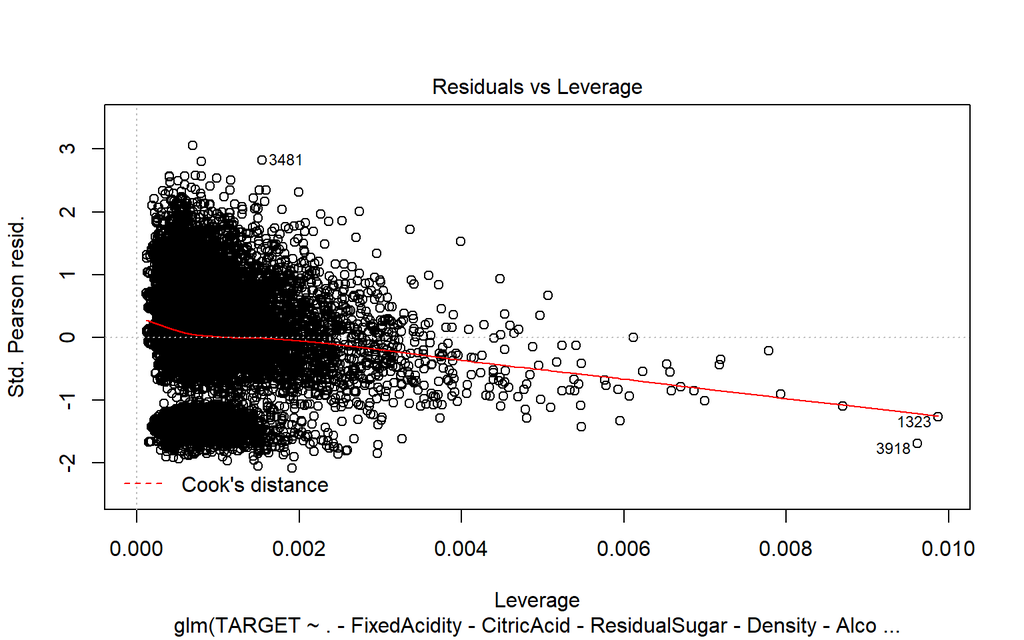

### Model 5 : Negative Binomial Model without imputations

```
##
## Call:
## glm.nb(formula = TARGET ~ ., data = wine_train1, init.theta = 138898.9107,
##     link = log)
##
## Deviance Residuals:
##     Min       1Q   Median       3Q      Max
## -3.2127  -0.2757   0.0647   0.3766   1.6981
##
## Coefficients:
##                      Estimate Std. Error z value Pr(>|z|)
## (Intercept)         1.608e+00  2.796e-01   5.750 8.91e-09 ***
## FixedAcidity        6.705e-04  1.177e-03   0.570  0.56900
## VolatileAcidity    -2.750e-02  9.283e-03  -2.963  0.00305 **
## CitricAcid         -3.835e-03  8.519e-03  -0.450  0.65259
## ResidualSugar       1.828e-05  2.152e-04   0.085  0.93231
## Chlorides          -3.764e-02  2.314e-02  -1.627  0.10378
## FreeSulfurDioxide   5.671e-05  4.892e-05   1.159  0.24630
## TotalSulfurDioxide  2.230e-05  3.177e-05   0.702  0.48275
## Density            -4.025e-01  2.750e-01  -1.464  0.14326
## pH                  2.307e-04  1.085e-02   0.021  0.98303
## Sulphates          -5.984e-03  7.973e-03  -0.751  0.45293
## Alcohol             3.262e-03  2.004e-03   1.628  0.10360
## LabelAppeal         1.730e-01  8.858e-03  19.529  < 2e-16 ***
## AcidIndex          -4.967e-02  6.666e-03  -7.451 9.28e-14 ***
## STARS               1.929e-01  8.328e-03  23.160  < 2e-16 ***
## ---
## Signif. codes:  0 '***' 0.001 '**' 0.01 '*' 0.05 '.' 0.1 ' ' 1
##
## (Dispersion parameter for Negative Binomial(138898.9) family taken to be 1)
##
##     Null deviance: 4720.4  on 5143  degrees of freedom
## Residual deviance: 3242.7  on 5129  degrees of freedom
##   (5093 observations deleted due to missingness)
## AIC: 18547
##
## Number of Fisher Scoring iterations: 1
##
##
##               Theta:  138899
##           Std. Err.:  259921
## Warning while fitting theta: iteration limit reached
##
##  2 x log-likelihood:  -18515.07
```

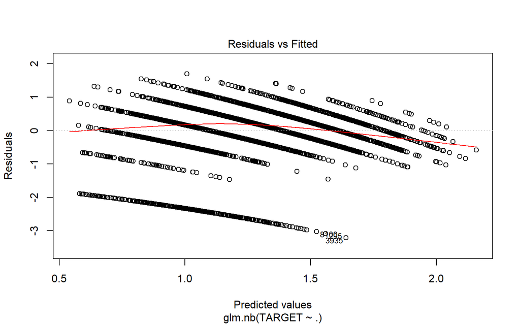

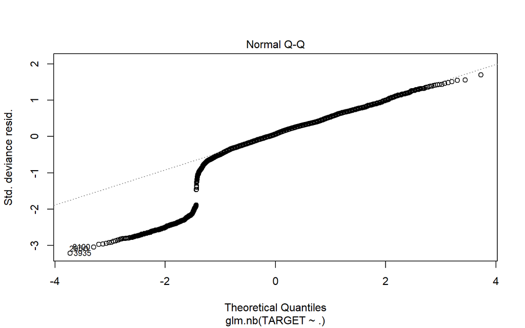

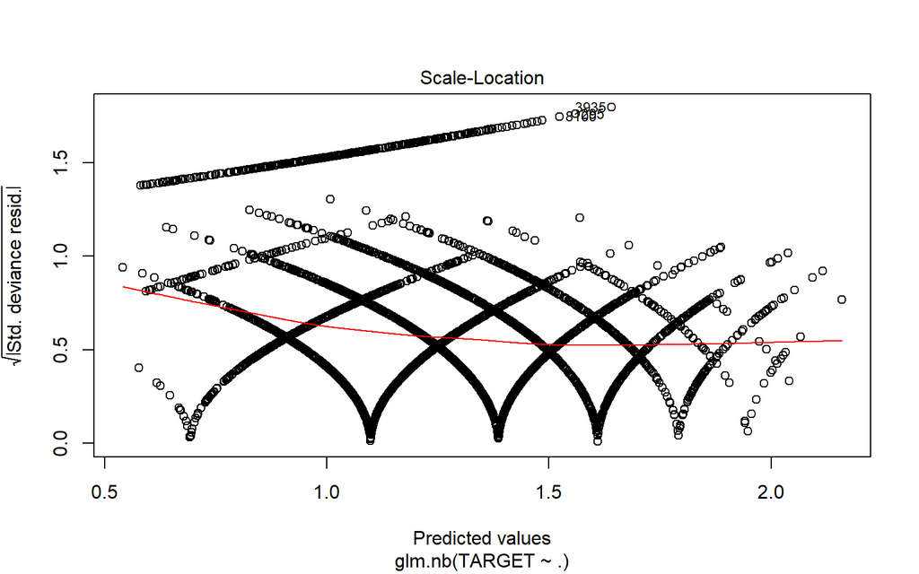

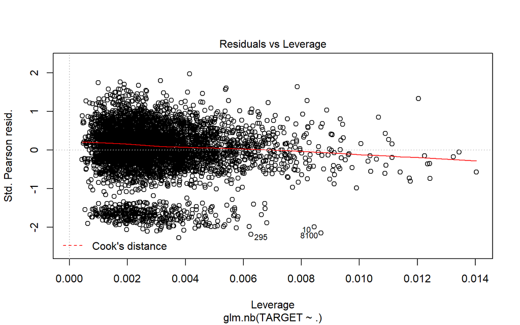

```
##
## Call:
## glm.nb(formula = TARGET ~ . - FixedAcidity - CitricAcid - ResidualSugar -
##     Chlorides - FreeSulfurDioxide - TotalSulfurDioxide - Density -
##     pH - Sulphates - Alcohol, data = wine_train1, init.theta = 138402.5261,
##     link = log)
##
## Deviance Residuals:
##     Min       1Q   Median       3Q      Max
## -3.1898  -0.2777   0.0622   0.3764   1.6086
##
## Coefficients:
##                  Estimate Std. Error z value Pr(>|z|)
## (Intercept)      1.251443   0.054725  22.868  < 2e-16 ***
## VolatileAcidity -0.027581   0.009279  -2.973  0.00295 **
## LabelAppeal      0.173177   0.008853  19.562  < 2e-16 ***
## AcidIndex       -0.050616   0.006553  -7.724 1.13e-14 ***
## STARS            0.194209   0.008292  23.421  < 2e-16 ***
## ---
## Signif. codes:  0 '***' 0.001 '**' 0.01 '*' 0.05 '.' 0.1 ' ' 1
##
## (Dispersion parameter for Negative Binomial(138402.5) family taken to be 1)
##
##     Null deviance: 4720.4  on 5143  degrees of freedom
## Residual deviance: 3253.0  on 5139  degrees of freedom
##   (5093 observations deleted due to missingness)
## AIC: 18537
##
## Number of Fisher Scoring iterations: 1
##
##
##               Theta:  138403
##           Std. Err.:  258834
## Warning while fitting theta: iteration limit reached
##
##  2 x log-likelihood:  -18525.37
```

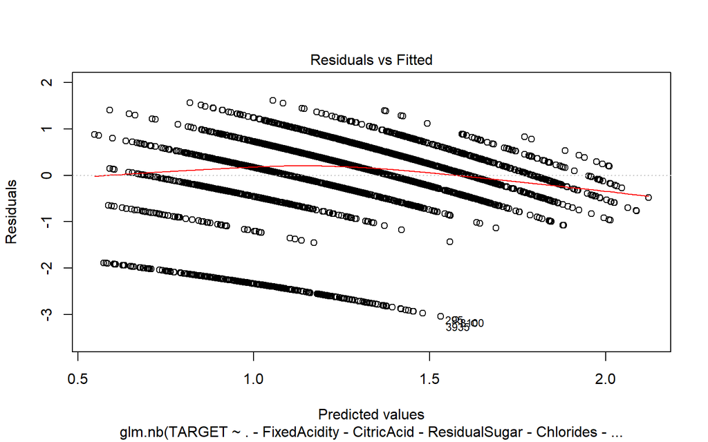

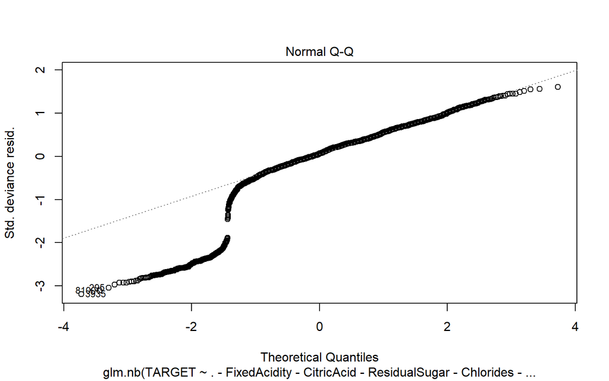

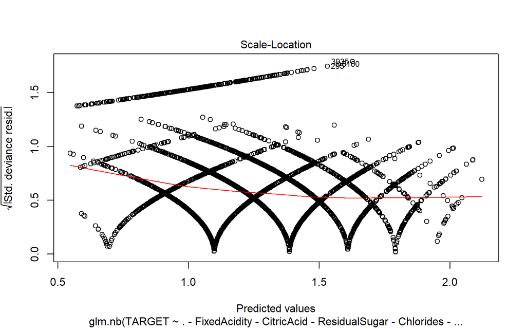